# Project #2

El objetivo de este proyecto es construir modelos de aprendizaje automático para un conjunto de datos y evaluar los modelos. Comenzaremos limpiando el conjunto de datos y luego construiremos modelos de aprendizaje automático de acuerdo con el resumen proporcionado. Obtendremos resultados significativos de los modelos y los compararemos entre sí para encontrar el mejor modelo.

El conjunto de datos es un archivo CSV que contiene datos sobre la pérdida de clientes de la industria de las telecomunicaciones. La deserción es una métrica importante que las empresas deben analizar porque las tasas de abandono altas indican clientes insatisfechos, mientras que las tasas de abandono bajas indican clientes satisfechos, es decir, es menos probable que los clientes abandonen esta empresa y lleven su negocio a otra parte. Por lo tanto, es importante que las empresas puedan comprender sus tasas de abandono, predecir las tasas de abandono futuras y optimizar sus servicios para tener índices de abandono bajos y continuos.

Según el informe, debemos utilizar los siguientes cuatro algoritmos en el conjunto de datos para derivar predicciones sobre la rotación de clientes:

1. Naive Bayes
2. Logistic Regression
3. Random Forest
4. XGBoost

Utilizamos estos cuatro modelos en tres etapas de análisis:

1. técnicas normales para predicciones
2. Uso de técnicas SMOTE para abordar el desequilibrio de datos en las predicciones.
3. normalmente, pero usando ajuste de hiperparámetros para optimizar el modelo para las predicciones (solo Random Forest y XGBoost)

Compararemos las siguientes métricas para cada modelo y etapa de análisis:

1. Exactitud
2. Precisión
3. Recordar
4. Puntuación F1

Usaremos Recall como métrica definitoria para evaluar estos modelos y etapas de análisis. Finalmente, evaluaremos el mejor modelo y etapa de análisis para este conjunto de datos para predecir la deserción.

## 1. Preparación de datos

```python
# importar librerias para limpieza de datos, visualización y EDA
import numpy as np
import matplotlib.pyplot as plt
import pandas as pd
import seaborn as sns
import plotly
import statsmodels
from sklearn.model_selection import train_test_split, GridSearchCV, RandomizedSearchCV
from sklearn.naive_bayes import GaussianNB
from sklearn.linear_model import LogisticRegression
from sklearn.ensemble import RandomForestRegressor
from sklearn.metrics import accuracy_score, recall_score, precision_score, f1_score, confusion_matrix
from sklearn.metrics import ConfusionMatrixDisplay
import xgboost as xgb
from xgboost import XGBRegressor
from imblearn.over_sampling import SMOTE
import warnings
warnings.filterwarnings("ignore", category=DeprecationWarning)
warnings.filterwarnings("ignore", category=FutureWarning)
```

```python
# leer el archivo de datos CSV sin procesar
df = pd.read_csv("telco-customer-churn.csv")
```

```python
df.head()
```

|  | customerID | gender | SeniorCitizen | Partner | Dependents | tenure | PhoneService | MultipleLines | InternetService | OnlineSecurity | ... | DeviceProtection | TechSupport | StreamingTV | StreamingMovies | Contract | PaperlessBilling | PaymentMethod | MonthlyCharges | TotalCharges | Churn |
| --- | --- | --- | --- | --- | --- | --- | --- | --- | --- | --- | --- | --- | --- | --- | --- | --- | --- | --- | --- | --- | --- |
| 0 | 7590-VHVEG | Female | 0 | Yes | No | 1 | No | No phone service | DSL | No | ... | No | No | No | No | Month-to-month | Yes | Electronic check | 29.85 | 29.85 | No |
| 1 | 5575-GNVDE | Male | 0 | No | No | 34 | Yes | No | DSL | Yes | ... | Yes | No | No | No | One year | No | Mailed check | 56.95 | 1889.5 | No |
| 2 | 3668-QPYBK | Male | 0 | No | No | 2 | Yes | No | DSL | Yes | ... | No | No | No | No | Month-to-month | Yes | Mailed check | 53.85 | 108.15 | Yes |
| 3 | 7795-CFOCW | Male | 0 | No | No | 45 | No | No phone service | DSL | Yes | ... | Yes | Yes | No | No | One year | No | Bank transfer (automatic) | 42.30 | 1840.75 | No |
| 4 | 9237-HQITU | Female | 0 | No | No | 2 | Yes | No | Fiber optic | No | ... | No | No | No | No | Month-to-month | Yes | Electronic check | 70.70 | 151.65 | Yes |

5 rows × 21 columns

```python
# obtener valores únicos de cada columna, para que sepamos qué valores convertir a numéricos
for col in df.columns:
    print(col,df[col].unique())
```

```
customerID ['7590-VHVEG' '5575-GNVDE' '3668-QPYBK' ... '4801-JZAZL' '8361-LTMKD'
 '3186-AJIEK']
gender ['Female' 'Male']
SeniorCitizen [0 1]
Partner ['Yes' 'No']
Dependents ['No' 'Yes']
tenure [ 1 34  2 45  8 22 10 28 62 13 16 58 49 25 69 52 71 21 12 30 47 72 17 27
  5 46 11 70 63 43 15 60 18 66  9  3 31 50 64 56  7 42 35 48 29 65 38 68
 32 55 37 36 41  6  4 33 67 23 57 61 14 20 53 40 59 24 44 19 54 51 26  0
 39]
PhoneService ['No' 'Yes']
MultipleLines ['No phone service' 'No' 'Yes']
InternetService ['DSL' 'Fiber optic' 'No']
OnlineSecurity ['No' 'Yes' 'No internet service']
OnlineBackup ['Yes' 'No' 'No internet service']
DeviceProtection ['No' 'Yes' 'No internet service']
TechSupport ['No' 'Yes' 'No internet service']
StreamingTV ['No' 'Yes' 'No internet service']
StreamingMovies ['No' 'Yes' 'No internet service']
Contract ['Month-to-month' 'One year' 'Two year']
PaperlessBilling ['Yes' 'No']
PaymentMethod ['Electronic check' 'Mailed check' 'Bank transfer (automatic)'
 'Credit card (automatic)']
MonthlyCharges [29.85 56.95 53.85 ... 63.1  44.2  78.7 ]
TotalCharges ['29.85' '1889.5' '108.15' ... '346.45' '306.6' '6844.5']
Churn ['No' 'Yes']
```

```python
# realizar codificación de etiquetas
for col in df.columns:
    # solo usaremos 0 y 1 para valores binarios
    df.loc[df[col] == "Yes", col] = 1
    df.loc[df[col] == "No", col] = 0
    df.loc[df[col] == "Female", col] = 0
    df.loc[df[col] == "Male", col] = 1
    # todo lo demás lo representaremos con un entero distinto
    df.loc[df[col] == "No phone service", col] = 2
    df.loc[df[col] == "No internet service", col] = 3
    df.loc[df[col] == "DSL", col] = 4
    df.loc[df[col] == "Fiber optic", col] = 5
    df.loc[df[col] == "Month-to-month", col] = 6
    df.loc[df[col] == "One year", col] = 7
    df.loc[df[col] == "Two year", col] = 8
    df.loc[df[col] == "Electronic check", col] = 9
    df.loc[df[col] == "Mailed check", col] = 10
    df.loc[df[col] == "Bank transfer (automatic)", col] = 11
    df.loc[df[col] == "Credit card (automatic)", col] = 12
    # estableceremos los valores faltantes en -1, para que sepamos que corresponden a los valores faltantes
    df.loc[df[col] == " ", col] = -1
```

```python
# obteniendo la lista de todas las columnas que necesitamos convertir
cols_to_convert_to_int = df.columns[np.where(df.dtypes=="object")]
cols_to_convert_to_int = cols_to_convert_to_int[1:] # we are excluding the customerID column
```

```python
# convertir cada una de las columnas objetivo a tipo entero
for col in cols_to_convert_to_int:
    df[col] = pd.to_numeric(df[col])
```

```python
# comprobando los tipos de datos
df.dtypes
```

```
customerID           object
gender                int64
SeniorCitizen         int64
Partner               int64
Dependents            int64
tenure                int64
PhoneService          int64
MultipleLines         int64
InternetService       int64
OnlineSecurity        int64
OnlineBackup          int64
DeviceProtection      int64
TechSupport           int64
StreamingTV           int64
StreamingMovies       int64
Contract              int64
PaperlessBilling      int64
PaymentMethod         int64
MonthlyCharges      float64
TotalCharges        float64
Churn                 int64
dtype: object
```

```python
df = df.drop([0])  # estamos excluyendo la columna ID de cliente
```

Now that we have a dataset ready for analysis, we will split the dataset into training and testing splits, using the 80/20% ratio.

```python
X = df.drop(['customerID','Churn'],axis=1)
Y = df['Churn']
# dividir los datos en un conjunto de 80% de entrenamiento/20% de prueba
X_train, X_test, Y_train, Y_test = train_test_split(X, Y, test_size=0.2, random_state=42)
```

```python
# definir algunos dfs vacíos para registrar métricas de cada modelo y etapa de análisis
column_names = ["method","accuracy","precision","recall","f1"]
final_results_no_smote = pd.DataFrame(columns=column_names)
final_results_smote = pd.DataFrame(columns=column_names)
final_results_hyp = pd.DataFrame(columns=column_names)
```

## Primera etapa del análisis: predicciones normales

En esta sección, utilizaremos los cuatro algoritmos para generar predicciones de abandono.

### Naive Bayes

```python
# naive bayes
nb = GaussianNB()
nb.fit(X_train, Y_train)
nb_predictions = nb.predict(X_test)
```

```python
nb_accuracy_score = accuracy_score(Y_test,nb_predictions)
nb_precision_score = precision_score(Y_test,nb_predictions)
nb_recall_score = recall_score(Y_test,nb_predictions)
nb_f1_score = f1_score(Y_test,nb_predictions)
nb_confusion = confusion_matrix(Y_test,nb_predictions)
```

```python
final_results_no_smote.loc[len(final_results_no_smote)] = ["Naive Bayes",nb_accuracy_score,nb_precision_score,nb_recall_score,nb_f1_score]
```

### Logistic Regression

```python
lr = LogisticRegression(random_state=0)
lr.fit(X_train, Y_train)
lr_predictions = lr.predict(X_test)
```

```python
lr_accuracy_score = accuracy_score(Y_test,lr_predictions)
lr_precision_score = precision_score(Y_test,lr_predictions)
lr_recall_score = recall_score(Y_test,lr_predictions)
lr_f1_score = f1_score(Y_test,lr_predictions)
lr_confusion = confusion_matrix(Y_test,lr_predictions)
```

```python
final_results_no_smote.loc[len(final_results_no_smote)] = ["Logistic Regression",lr_accuracy_score,lr_precision_score,lr_recall_score,lr_f1_score]
```

### Random Forest

```python
rf = RandomForestRegressor(random_state = 42)
rf.fit(X_train, Y_train)
rf_predictions = rf.predict(X_test)
rf_predictions = [int(x) for x in np.round(rf_predictions,0)]
```

```python
rf_accuracy_score = accuracy_score(Y_test,rf_predictions)
rf_precision_score = precision_score(Y_test,rf_predictions)
rf_recall_score = recall_score(Y_test,rf_predictions)
rf_f1_score = f1_score(Y_test,rf_predictions)
rf_confusion = confusion_matrix(Y_test,rf_predictions)
```

```python
final_results_no_smote.loc[len(final_results_no_smote)] = ["Random Forest",rf_accuracy_score,rf_precision_score,rf_recall_score,rf_f1_score]
```

### XGBoost

```python
xgb_classifier = xgb.XGBClassifier()
xgb_classifier.fit(X_train,Y_train)
xgb_predictions = xgb_classifier.predict(X_test)
```

```python
xgb_accuracy_score = accuracy_score(Y_test,xgb_predictions)
xgb_precision_score = precision_score(Y_test,xgb_predictions)
xgb_recall_score = recall_score(Y_test,xgb_predictions)
xgb_f1_score = f1_score(Y_test,xgb_predictions)
xgb_confusion = confusion_matrix(Y_test,xgb_predictions)
```

```python
final_results_no_smote.loc[len(final_results_no_smote)] = ["XGBoost",xgb_accuracy_score,xgb_precision_score,xgb_recall_score,xgb_f1_score]
```

### Comparación de resultados para la etapa uno del análisis

Ahora que hemos creado los cuatro modelos para esta etapa de análisis (sin SMOTE), compararemos las métricas de estos modelos.

```python
# examinando la tabla de datos para esta etapa de análisis

final_results_no_smote
```

|  | method | accuracy | precision | recall | f1 |
| --- | --- | --- | --- | --- | --- |
| 0 | Naive Bayes | 0.652236 | 0.415323 | 0.848901 | 0.557762 |
| 1 | Logistic Regression | 0.810504 | 0.652038 | 0.571429 | 0.609078 |
| 2 | Random Forest | 0.789922 | 0.604938 | 0.538462 | 0.569767 |
| 3 | XGBoost | 0.800568 | 0.625378 | 0.568681 | 0.595683 |

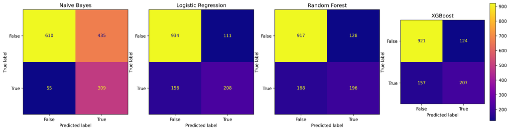

```python
# comparando matrices de confusión para esta etapa de análisis
x_labels = final_results_no_smote['method']
indices = np.arange(len(x_labels))

fig, ax = plt.subplots(1,4,sharex=True, sharey=False, figsize=(20, 5), dpi=300)
ax[0].set_title(x_labels[0])
ax[1].set_title(x_labels[1])
ax[2].set_title(x_labels[2])
ax[3].set_title(x_labels[3])

ConfusionMatrixDisplay(nb_confusion,display_labels=[False,True]).plot(ax=ax[0],cmap='plasma',colorbar=False)
ConfusionMatrixDisplay(lr_confusion,display_labels=[False,True]).plot(ax=ax[1],cmap='plasma',colorbar=False)
ConfusionMatrixDisplay(rf_confusion,display_labels=[False,True]).plot(ax=ax[2],cmap='plasma',colorbar=False)
ConfusionMatrixDisplay(xgb_confusion,display_labels=[False,True]).plot(ax=ax[3],cmap='plasma',colorbar=True)
fig.show()
```

Vemos que para esta etapa de análisis, el modelo Naive Bayes tiene la matriz de confusión más variada, en términos de negativos y positivos, sin embargo tiene el menor número de Verdaderos Negativos, en comparación con los otros tres modelos. Los otros tres modelos tienen proporciones consistentes (entre sí) de Negativos y Positivos.

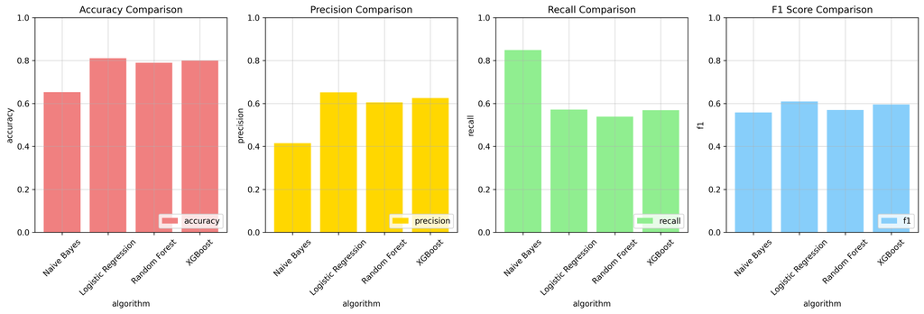

```python
# comparando todas las métricas para esta etapa de análisis
fig, ax = plt.subplots(1, 4, sharex=True, sharey=False, figsize=(20, 5), dpi=300)
x_labels = final_results_no_smote['method']
indices = np.arange(len(x_labels))
width = 0.3

# primera fila - SIN hiperparámetros
#row=0, col=0
ax[0].bar(indices,final_results_no_smote['accuracy'],color="lightcoral",alpha=1,label="accuracy")
ax[0].grid(True,alpha=0.5)
ax[0].set_ylim(0,1)
ax[0].set_xlabel("algorithm")
ax[0].set_ylabel("accuracy")
ax[0].set_title("Accuracy Comparison")
ax[0].legend(loc='lower right')
ax[0].set_xticks(indices, x_labels, rotation=45)

#row=0, col=1
ax[1].bar(indices,final_results_no_smote['precision'],color="gold",alpha=1,label="precision")
ax[1].grid(True,alpha=0.5)
ax[1].set_ylim(0,1)
ax[1].set_xlabel("algorithm")
ax[1].set_ylabel("precision")
ax[1].set_title("Precision Comparison")
ax[1].legend(loc='lower right')
ax[1].set_xticks(indices, x_labels, rotation=45)

#row=0, col=2
ax[2].bar(indices,final_results_no_smote['recall'],color="lightgreen",alpha=1,label="recall")
ax[2].grid(True,alpha=0.5)
ax[2].set_ylim(0,1)
ax[2].set_xlabel("algorithm")
ax[2].set_ylabel("recall")
ax[2].set_title("Recall Comparison")
ax[2].legend(loc='lower right')
ax[2].set_xticks(indices, x_labels, rotation=45)

#row=0, col=3
ax[3].bar(indices,final_results_no_smote['f1'],color="lightskyblue",alpha=1,label="f1")
ax[3].grid(True,alpha=0.5)
ax[3].set_ylim(0,1)
ax[3].set_xlabel("algorithm")
ax[3].set_ylabel("f1")
ax[3].set_title("F1 Score Comparison")
ax[3].legend(loc='lower right')
ax[3].set_xticks(indices, x_labels, rotation=45)
```

Vemos que para esta etapa de análisis, el clasificador Naive Bayes tiene el mayor recuerdo. Dado que lo que nos preocupa es la métrica de recuperación, en este caso, el clasificador Naive Bayes es el mejor algoritmo para predecir la deserción en este conjunto de datos.

Etapa dos del análisis: predicciones utilizando SMOTE

Ahora repetiremos el mismo proceso anterior, es decir, entrenar el conjunto de datos utilizando los cuatro algoritmos y generar predicciones para la pérdida de clientes. Sin embargo, esta vez utilizaremos la metodología SMOTE (Synthetic Minority Oversampling TechniquE). Este método aborda los desequilibrios en el conjunto de datos con respecto a las etiquetas de clasificación. Normalmente, debido al desequilibrio de clases, la clase mayoritaria tendrá mejor desempeño que la clase minoritaria. SMOTE se ocupa de esto sobremuestreando la clase minoritaria.

```python
X = df.drop(['customerID','Churn'],axis=1)
Y = df['Churn']
# dividir los datos en un conjunto de 80% de entrenamiento/20% de prueba
X_train, X_test, Y_train, Y_test = train_test_split(X, Y, test_size=0.2, random_state=42)
```

```python
# implementando SMOTE
sm = SMOTE(random_state=42)
X_res, Y_res = sm.fit_resample(X_train, Y_train)
```

### Naive Bayes (SMOTE)

```python
# naive bayes
nb_smote = GaussianNB()
nb_smote.fit(X_res, Y_res)
nb_smote_predictions = nb_smote.predict(X_test)
```

```python
nb_smote_accuracy_score = accuracy_score(Y_test,nb_smote_predictions)
nb_smote_precision_score = precision_score(Y_test,nb_smote_predictions)
nb_smote_recall_score = recall_score(Y_test,nb_smote_predictions)
nb_smote_f1_score = f1_score(Y_test,nb_smote_predictions)
nb_smote_confusion = confusion_matrix(Y_test,nb_smote_predictions)
```

```python
final_results_smote.loc[len(final_results_smote)] = ["Naive Bayes",nb_smote_accuracy_score,nb_smote_precision_score,nb_smote_recall_score,nb_smote_f1_score]
```

### Logistic Regression (SMOTE)

```python
lr_smote = LogisticRegression(random_state=0)
lr_smote.fit(X_res, Y_res)
lr_smote_predictions = lr_smote.predict(X_test)
```

```python
lr_smote_accuracy_score = accuracy_score(Y_test,lr_smote_predictions)
lr_smote_precision_score = precision_score(Y_test,lr_smote_predictions)
lr_smote_recall_score = recall_score(Y_test,lr_smote_predictions)
lr_smote_f1_score = f1_score(Y_test,lr_smote_predictions)
lr_smote_confusion = confusion_matrix(Y_test,lr_smote_predictions)
```

```python
final_results_smote.loc[len(final_results_smote)] = ["Logistic Regression",lr_smote_accuracy_score,lr_smote_precision_score,lr_smote_recall_score,lr_smote_f1_score]
```

### Random Forest (SMOTE)

```python
rf_smote = RandomForestRegressor(n_estimators = 1000, random_state = 42)
rf_smote.fit(X_res, Y_res)
rf_smote_predictions = rf_smote.predict(X_test)
rf_smote_predictions = [int(x) for x in np.round(rf_smote_predictions,0)]
```

```python
rf_smote_accuracy_score = accuracy_score(Y_test,rf_smote_predictions)
rf_smote_precision_score = precision_score(Y_test,rf_smote_predictions)
rf_smote_recall_score = recall_score(Y_test,rf_smote_predictions)
rf_smote_f1_score = f1_score(Y_test,rf_smote_predictions)
rf_smote_confusion = confusion_matrix(Y_test,rf_smote_predictions)
```

```python
final_results_smote.loc[len(final_results_smote)] = ["Random Forest",rf_smote_accuracy_score,rf_smote_precision_score,rf_smote_recall_score,rf_smote_f1_score]
```

### XGB Boost (SMOTE)

```python
xgb_smote = xgb.XGBClassifier()
xgb_smote.fit(X_res, Y_res)
xgb_smote_predictions = xgb_smote.predict(X_test)
```

```python
xgb_smote_accuracy_score = accuracy_score(Y_test,xgb_smote_predictions)
xgb_smote_precision_score = precision_score(Y_test,xgb_smote_predictions)
xgb_smote_recall_score = recall_score(Y_test,xgb_smote_predictions)
xgb_smote_f1_score = f1_score(Y_test,xgb_smote_predictions)
xgb_smote_confusion = confusion_matrix(Y_test,xgb_smote_predictions)
```

```python
final_results_smote.loc[len(final_results_smote)] = ["XGBoost",xgb_smote_accuracy_score,xgb_smote_precision_score,xgb_smote_recall_score,xgb_smote_f1_score]
```

### Comparación de resultados para la segunda etapa del análisis

Ahora que hemos creado los cuatro modelos para esta etapa de análisis (SMOTE), compararemos las métricas de estos modelos.

```python
# examinando la tabla de datos para esta etapa de análisis
final_results_smote
```

|  | method | accuracy | precision | recall | f1 |
| --- | --- | --- | --- | --- | --- |
| 0 | Naive Bayes | 0.668559 | 0.427567 | 0.835165 | 0.565581 |
| 1 | Logistic Regression | 0.740241 | 0.498148 | 0.739011 | 0.595133 |
| 2 | Random Forest | 0.777147 | 0.561576 | 0.626374 | 0.592208 |
| 3 | XGBoost | 0.761533 | 0.534653 | 0.593407 | 0.562500 |

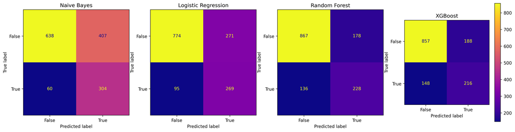

```python
# Comparar matrices de confusión para esta etapa de análisis
fig, ax = plt.subplots(1,4,sharex=False, sharey=False, figsize=(20, 5), dpi=300)
ax[0].set_title(x_labels[0])
ax[1].set_title(x_labels[1])
ax[2].set_title(x_labels[2])
ax[3].set_title(x_labels[3])

ConfusionMatrixDisplay(nb_smote_confusion,display_labels=[False,True]).plot(ax=ax[0],cmap='plasma',colorbar=False)
ConfusionMatrixDisplay(lr_smote_confusion,display_labels=[False,True]).plot(ax=ax[1],cmap='plasma',colorbar=False)
ConfusionMatrixDisplay(rf_smote_confusion,display_labels=[False,True]).plot(ax=ax[2],cmap='plasma',colorbar=False)
ConfusionMatrixDisplay(xgb_smote_confusion,display_labels=[False,True]).plot(ax=ax[3],cmap='plasma',colorbar=True)
fig.show()
```

Encontramos que Naive Bayes tiene la matriz de confusión más variada, pero tiene el menor número de Verdaderos Negativos. Los otros tres modelos tienen proporciones similares entre sí en términos de Negativos y Positivos.

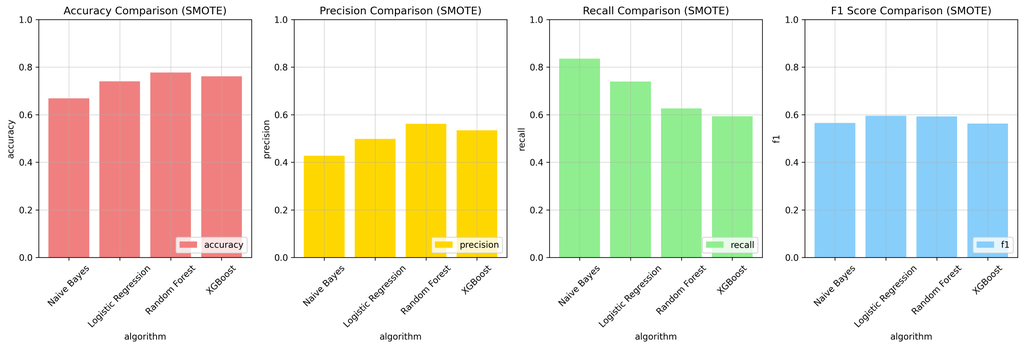

```python
# comparando todas las métricas para esta etapa de análisis
fig, ax = plt.subplots(1, 4, sharex=True, sharey=False, figsize=(20, 5), dpi=300)
x_labels = final_results_smote['method']
indices = np.arange(len(x_labels))
width = 0.3

# first row - NO Hyperparameters
#row=0, col=0
ax[0].bar(indices,final_results_smote['accuracy'],color="lightcoral",alpha=1,label="accuracy")
ax[0].grid(True,alpha=0.5)
ax[0].set_ylim(0,1)
ax[0].set_xlabel("algorithm")
ax[0].set_ylabel("accuracy")
ax[0].set_title("Accuracy Comparison (SMOTE)")
ax[0].legend(loc='lower right')
ax[0].set_xticks(indices, x_labels, rotation=45)

#row=0, col=1
ax[1].bar(indices,final_results_smote['precision'],color="gold",alpha=1,label="precision")
ax[1].grid(True,alpha=0.5)
ax[1].set_ylim(0,1)
ax[1].set_xlabel("algorithm")
ax[1].set_ylabel("precision")
ax[1].set_title("Precision Comparison (SMOTE)")
ax[1].legend(loc='lower right')
ax[1].set_xticks(indices, x_labels, rotation=45)

#row=0, col=2
ax[2].bar(indices,final_results_smote['recall'],color="lightgreen",alpha=1,label="recall")
ax[2].grid(True,alpha=0.5)
ax[2].set_ylim(0,1)
ax[2].set_xlabel("algorithm")
ax[2].set_ylabel("recall")
ax[2].set_title("Recall Comparison (SMOTE)")
ax[2].legend(loc='lower right')
ax[2].set_xticks(indices, x_labels, rotation=45)

#row=0, col=3
ax[3].bar(indices,final_results_smote['f1'],color="lightskyblue",alpha=1,label="f1")
ax[3].grid(True,alpha=0.5)
ax[3].set_ylim(0,1)
ax[3].set_xlabel("algorithm")
ax[3].set_ylabel("f1")
ax[3].set_title("F1 Score Comparison (SMOTE)")
ax[3].legend(loc='lower right')
ax[3].set_xticks(indices, x_labels, rotation=45)
```

En términos de recuperación, encontramos que el método Naive Bayes proporciona el mejor conjunto de predicciones de pérdida de clientes, en comparación con otros modelos.